# STA_380N_PART2_EXAM

### Portfolio 1 - 10 ETFs Balanced

We will consider the following portfolio for this case :

PORTFOLIO 1

| S.No | ETF | Definition |
| --- | --- | --- |
| 1 | WMT | Walmart |
| 2 | TGT | Target |
| 3 | XOM | Exxon Mobil |
| 4 | MRK | Merck |
| 5 | IDV | iShares International Select Dividend ETF |
| 6 | SPY | SPDR S&P 500 ETF Trust |
| 7 | VTI | Vanguard |
| 8 | DIA | Dow Jones Industrial |
| 9 | JNJ | Johnson and Johnson |
| 10 | URTY | Ultra share pro |

```
##  [1] "WMT"  "TGT"  "XOM"  "URTY" "JNJ"  "MRK"  "IDV"  "SPY"  "VTI"  "DIA"
```

```
## [1] "Combine all the returns in a matrix"
```

```
## [1] 102234.7
```

```
## [1] "Total wealth through 20 days"
```

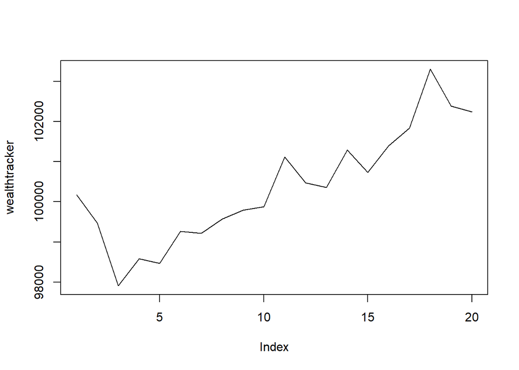

```
## [1] "Total wealth through simulate many different possible futures"
```

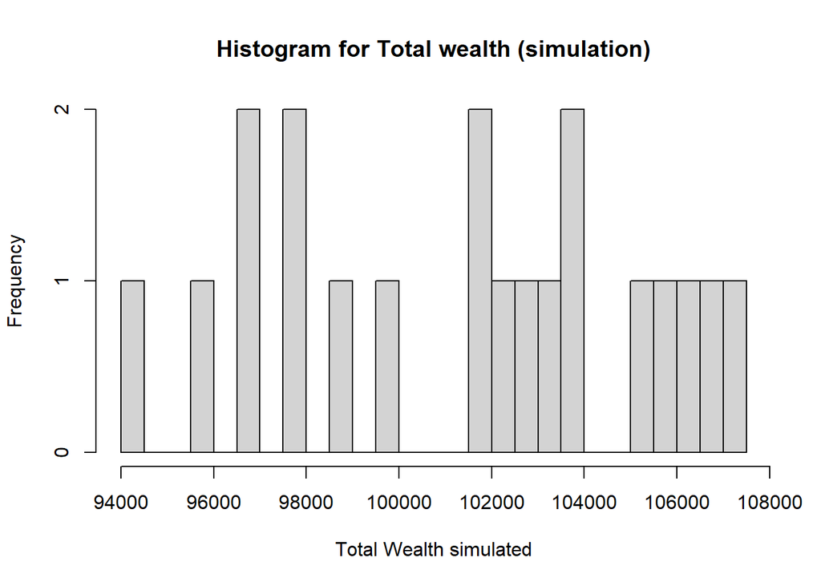

```
## [1] 101388.7
```

```
## [1] 1388.747
```

```
## [1] "Mean profit Loss"
```

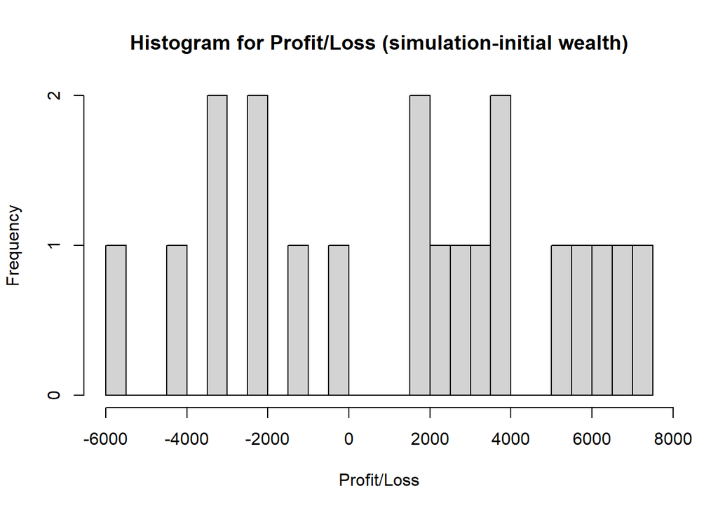

```
## [1] "5% value at risk"
```

```
##        5%
## -4292.916
```

This first portfolio performs well and this time with a -ve VAR value but a lower profit margin overall compared to our next portfolio. This is potentially due to the high number of stocks which can cause our profits to average out over the stocks that we have.

Let’s test out this theory by using a lower total number of stocks in our portfolio and try to measure the profit and VAR value.

### Portfolio 2 - 5 ETFs Risky and balanced

We will consider the following portfolio for this case :

PORTFOLIO 2

| S.No | ETF | Definition |
| --- | --- | --- |
| 1 | MRK | Merck |
| 2 | IDV | iShares International Select Dividend ETF |
| 3 | SPY | SPDR S&P 500 ETF Trust |
| 4 | VTI | Vanguard |
| 5 | DIA | Dow Jones Industrial |

```
## [1] "MRK" "IDV" "SPY" "VTI" "DIA"
```

```
## [1] 105635.8
```

```
## [1] "Total wealth through 20 days"
```

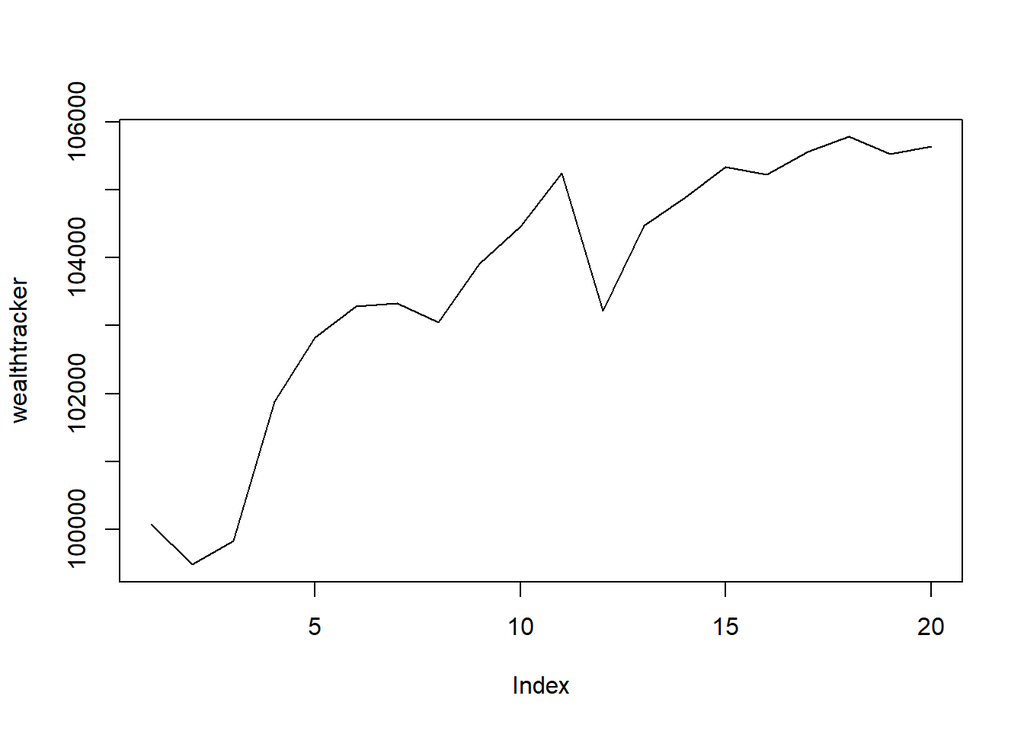

```
## [1] "Total wealth through simulate many different possible futures"
```

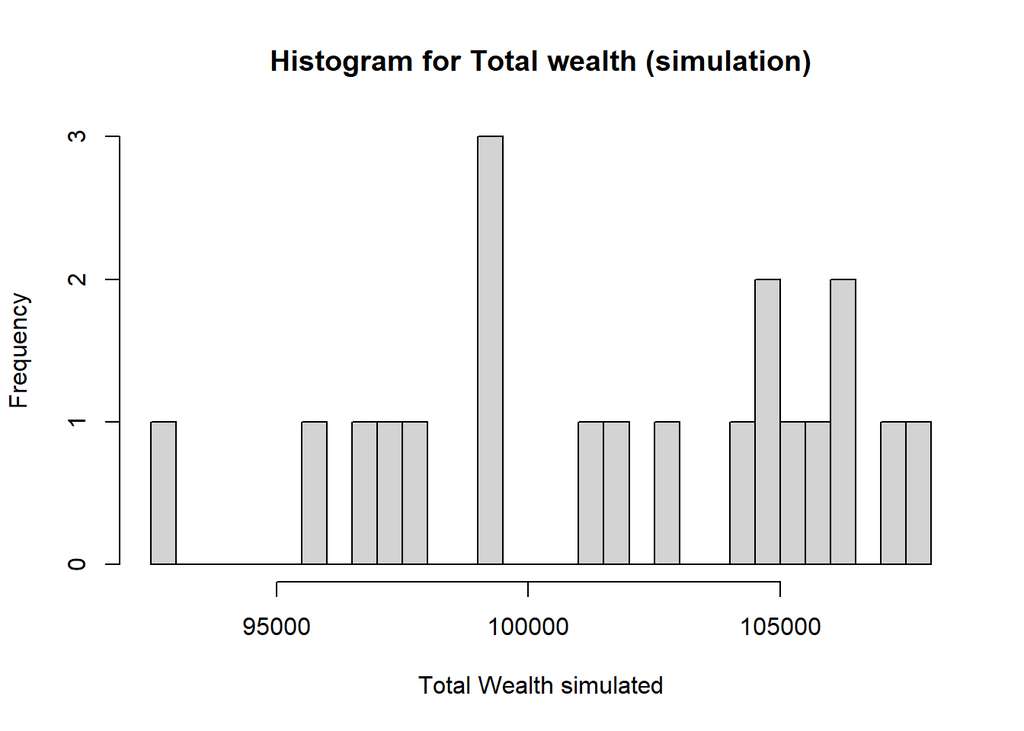

```
## [1] 101740.4
```

```
## [1] 1740.441
```

```
## [1] "Mean profit Loss"
```

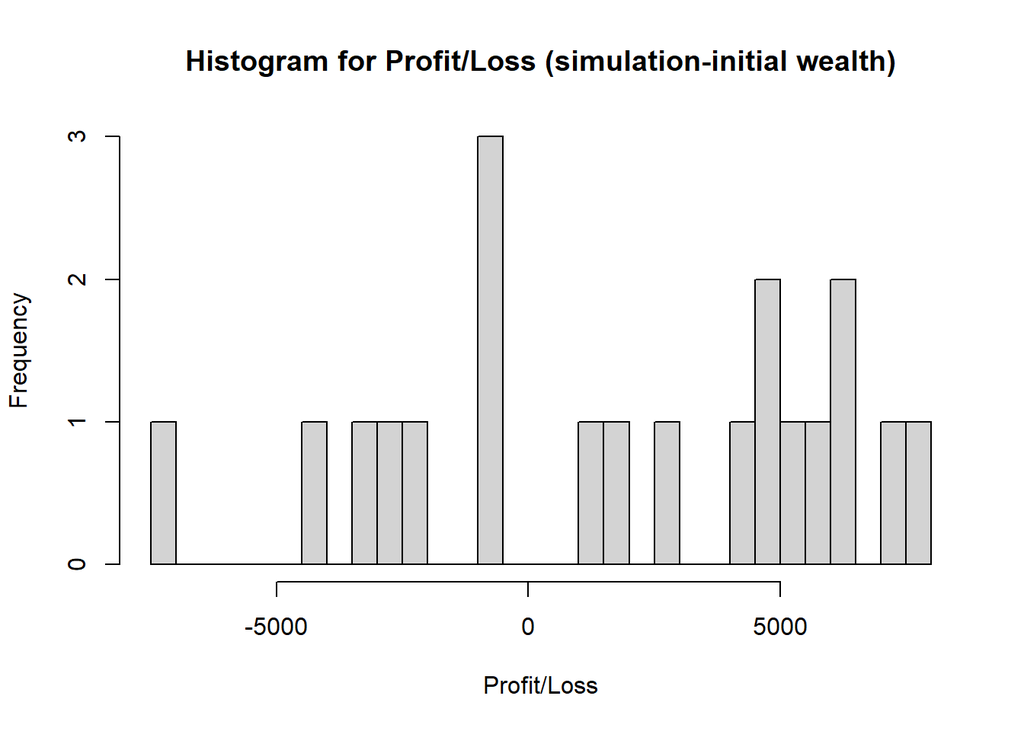

```
## [1] "5% value at risk"
```

```
##        5%
## -4517.566
```

### Portfolio 3 - Smallcap- Very Risky

PORTFOLIO 3

| S.No | ETF | Definition |
| --- | --- | --- |
| 1 | TNA | Direxion Daily Small Cap Bull 3x |
| 2 | URTY | ProShares UltraPro |
| 3 | UWM | ProShares Ultra |
| 4 | VTI | Vanguard |
| 5 | IWML | ETRACS 2x Leveraged U.S. Size Factor TR |

```
## [1] "TNA"  "URTY" "UWM"  "IWML" "VTI"
```

```
## [1] 118873.6
```

```
## [1] "Total wealth through 20 days"
```

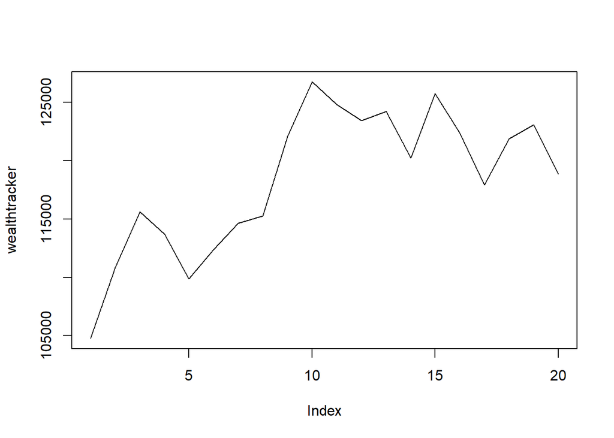

```
## [1] "Total wealth through simulate many different possible futures"
```

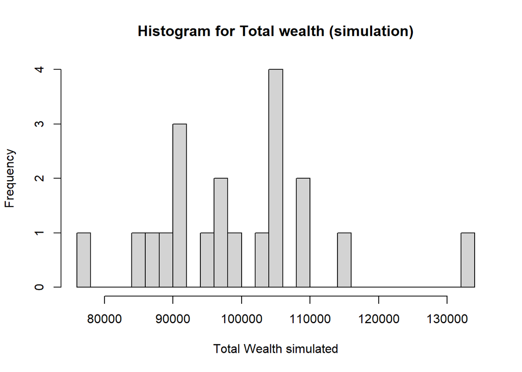

```
## [1] 99394.09
```

```
## [1] -605.9129
```

```
## [1] "Mean profit Loss"
```

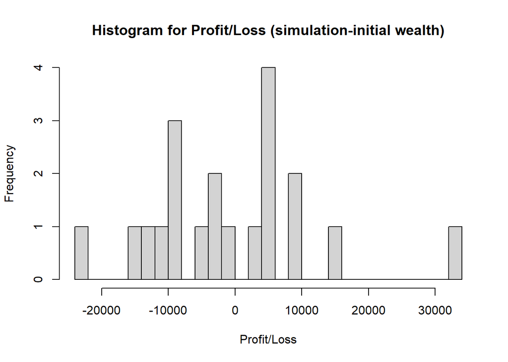

```
## [1] "5% value at risk"
```

```
##        5%
## -15676.04
```

## Clustering and PCA

The data in wine.csv contains information on 11 chemical properties of 6500 different bottles of *vinho verde* wine from northern Portugal. In addition, two other variables about each wine are recorded: - whether the wine is red or white  
- the quality of the wine, as judged on a 1-10 scale by a panel of certified wine snobs.

Run both PCA and a clustering algorithm of your choice on the 11 chemical properties (or suitable transformations thereof) and summarize your results. Which dimensionality reduction technique makes more sense to you for this data? Convince yourself (and me) that your chosen method is easily capable of distinguishing the reds from the whites, using only the “unsupervised” information contained in the data on chemical properties. Does your unsupervised technique also seem capable of distinguishing the higher from the lower quality wines?

To clarify: I’m not asking you to run an supervised learning algorithms. Rather, I’m asking you to see whether the differences in the labels (red/white and quality score) emerge naturally from applying an unsupervised technique to the chemical properties. This should be straightforward to assess using plots.

### Solution:

Let’s first look at Principal Component Analysis and if it can help us classify red and white wine.

Let’s look at the variances explained by different PC axes-

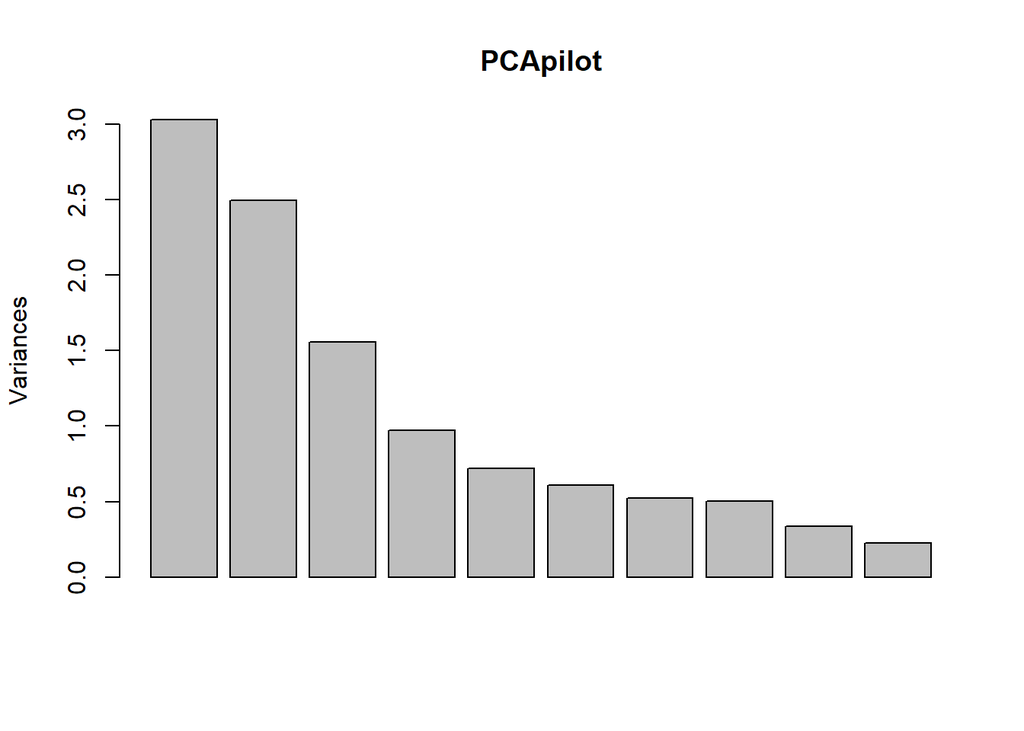

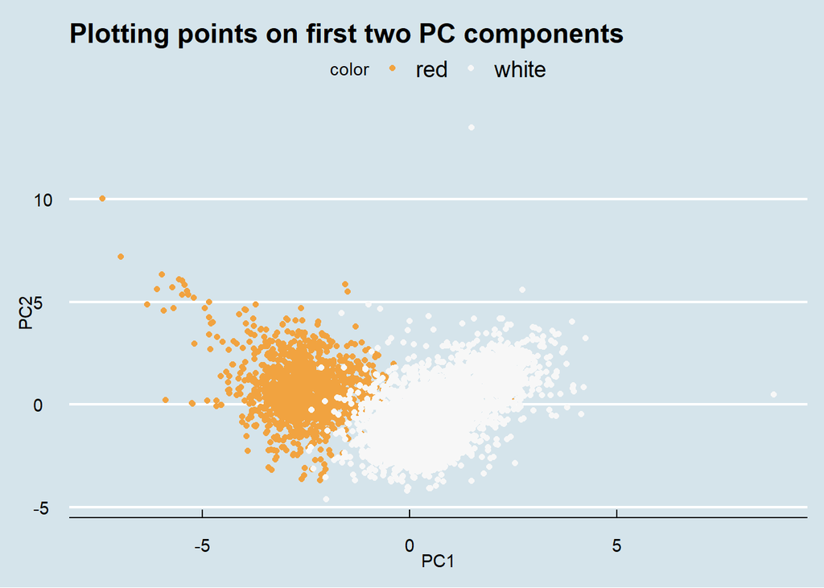

We can clearly see that the first two PC axes help us distinguish wine color!

However, in tyhe absence of the predicted variable such as color, let’s see what outr PCA plot looks like -

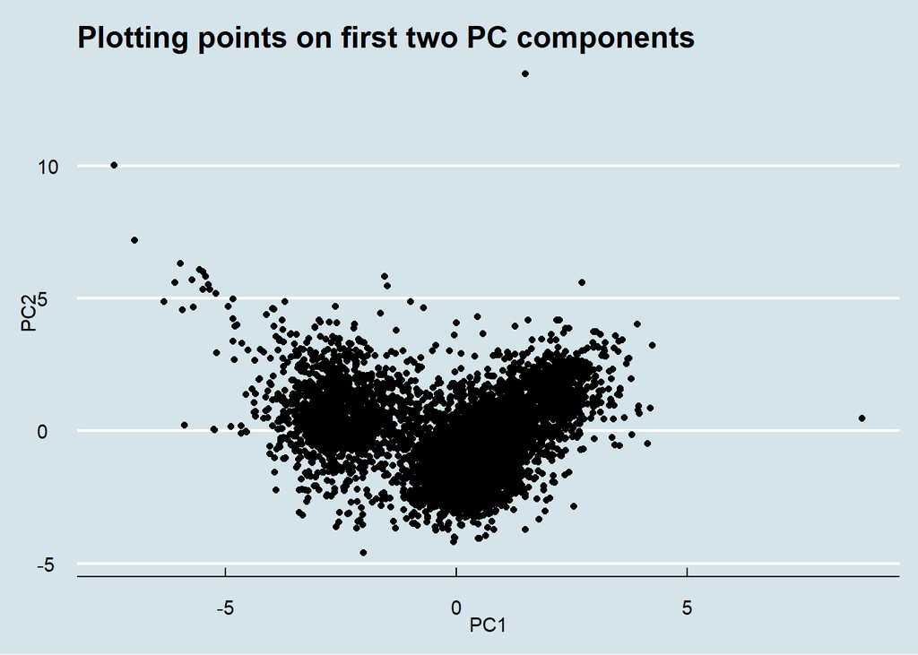

We can kind of see two different clusters without distinguiishing the points with the color related information we already have.

Let’s see if they help us distinguish quality -

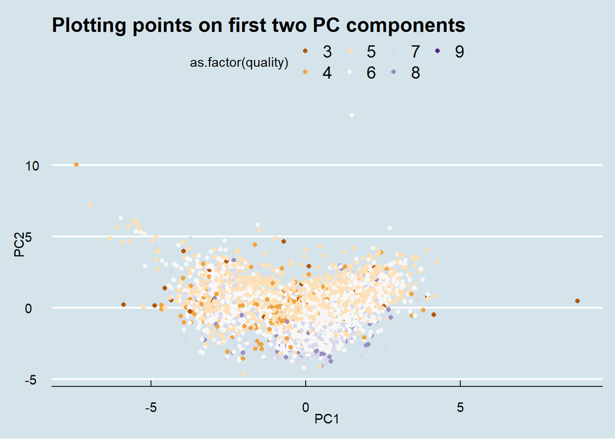

Nope! Does not help in distinguishing quality.

Let’s classify any wines with quality lesser or equal to 5 as ‘bad’ and greater than 5 as ‘good’. Maybe PCA could help classify wines in these simplified categories?

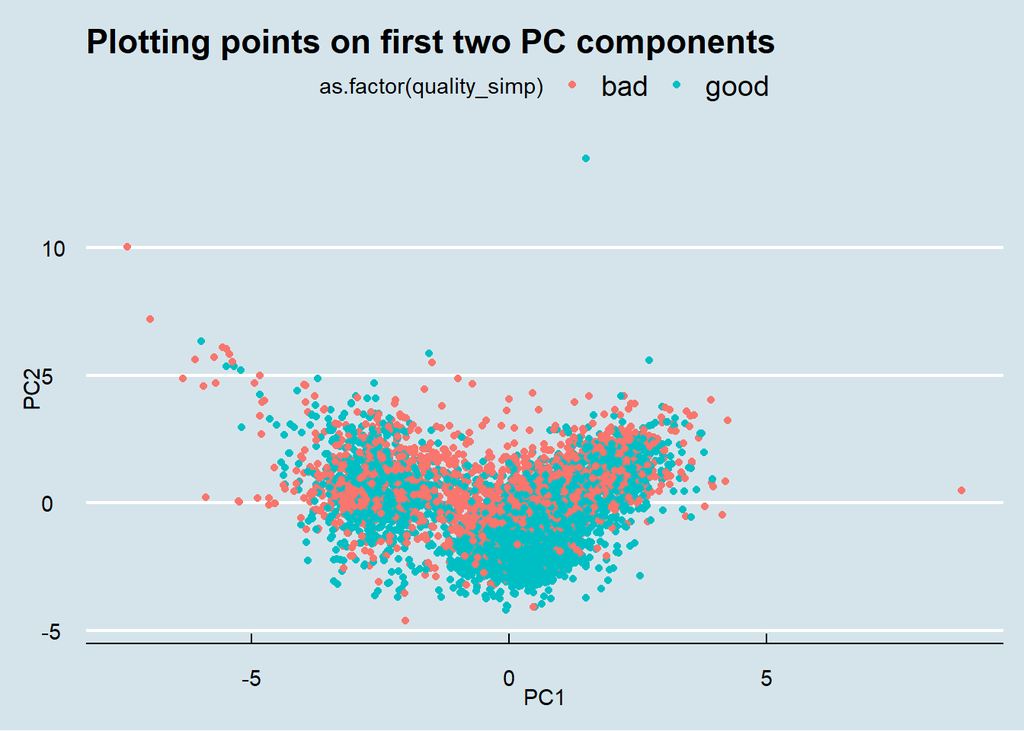

Nope, the data points with respect to quality cannot be distinguished even after simplifying the categories.

Let’s see if K-means clustering can classify color of wine as well.

Using simple K-means, let’s create 2 clusters and perform PCA. We can then plot the points wrt the first two PC axes, colour each point based on the cluster it’s assigned to and compare that plot to the PCA plot we got earlier.

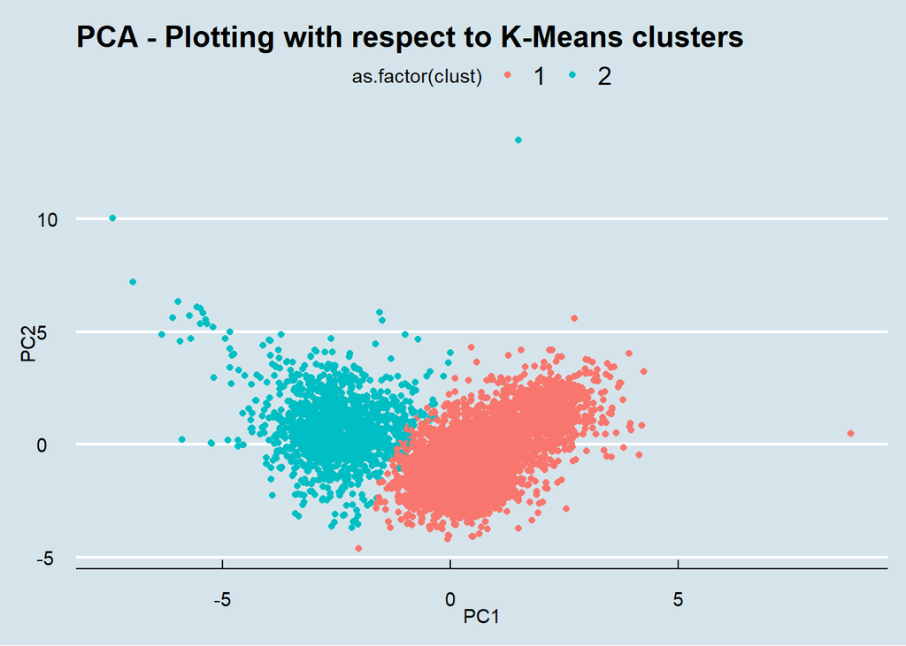

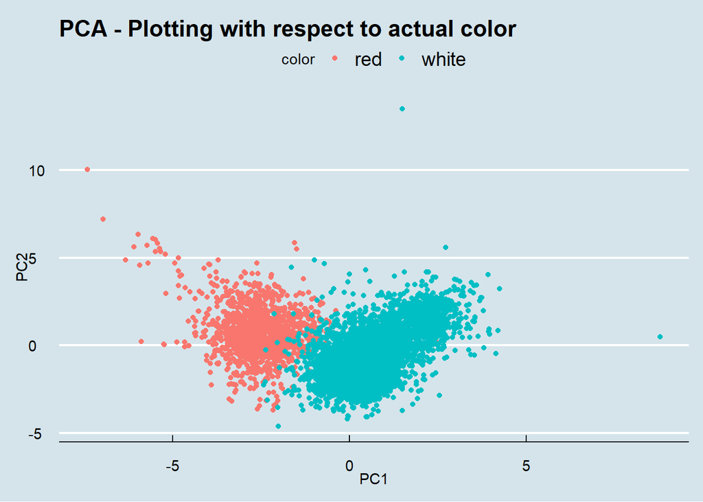

We can see that K-means performs pretty well in distinguishing the color of the wine except for a few outliers. However, if we plot the two clusters with beside the wine quality (good or bad) along the first two PC aces, we can see it doesn’t perform too well -

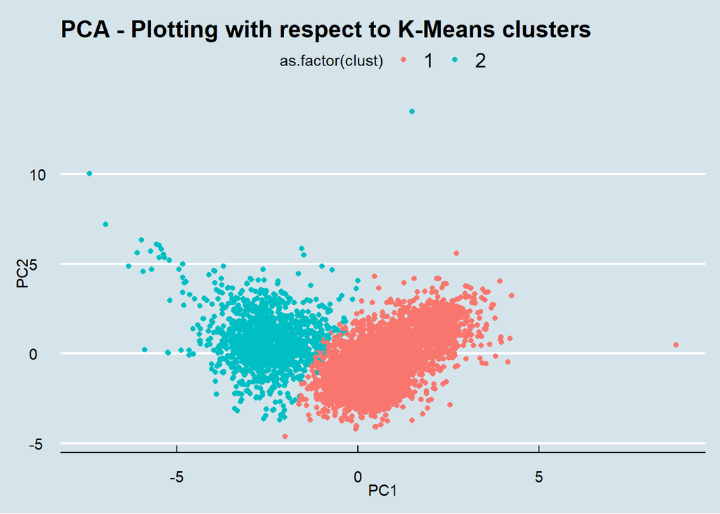

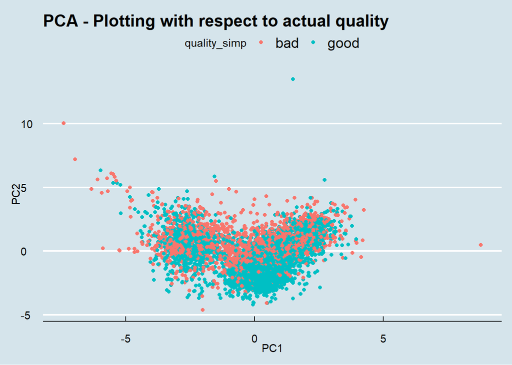

## Market segmentation

Consider the data in social_marketing.csv. This was data collected in the course of a market-research study using followers of the Twitter account of a large consumer brand that shall remain nameless—let’s call it “NutrientH20” just to have a label. The goal here was for NutrientH20 to understand its social-media audience a little bit better, so that it could hone its messaging a little more sharply.

A bit of background on the data collection: the advertising firm who runs NutrientH20’s online-advertising campaigns took a sample of the brand’s Twitter followers. They collected every Twitter post (“tweet”) by each of those followers over a seven-day period in June 2014. Every post was examined by a human annotator contracted through [Amazon’s Mechanical Turk](https://www.mturk.com/mturk/welcome) service. Each tweet was categorized based on its content using a pre-specified scheme of 36 different categories, each representing a broad area of interest (e.g. politics, sports, family, etc.) Annotators were allowed to classify a post as belonging to more than one category. For example, a hypothetical post such as “I’m really excited to see grandpa go wreck shop in his geriatic soccer league this Sunday!” might be categorized as both “family” and “sports.” You get the picture.

Each row of social_marketing.csv represents one user, labeled by a random (anonymous, unique) 9-digit alphanumeric code. Each column represents an interest, which are labeled along the top of the data file. The entries are the number of posts by a given user that fell into the given category. Two interests of note here are “spam” (i.e. unsolicited advertising) and “adult” (posts that are pornographic, salacious, or explicitly sexual). There are a lot of spam and pornography [“bots” on Twitter](http://mashable.com/2013/11/08/twitter-spambots/); while these have been filtered out of the data set to some extent, there will certainly be some that slip through. There’s also an “uncategorized” label. Annotators were told to use this sparingly, but it’s there to capture posts that don’t fit at all into any of the listed interest categories. (A lot of annotators may used the “chatter” category for this as well.) Keep in mind as you examine the data that you cannot expect perfect annotations of all posts. Some annotators might have simply been asleep at the wheel some, or even all, of the time! Thus there is some inevitable error and noisiness in the annotation process.

Your task to is analyze this data as you see fit, and to prepare a concise report for NutrientH20 that identifies any interesting market segments that appear to stand out in their social-media audience. You have complete freedom in deciding how to pre-process the data and how to define “market segment.” (Is it a group of correlated interests? A cluster? A latent factor? Etc.) Just use the data to come up with some interesting, well-supported insights about the audience, and be clear about what you did.

### Solution:

Let’s first look at a correlation graph of each interest -

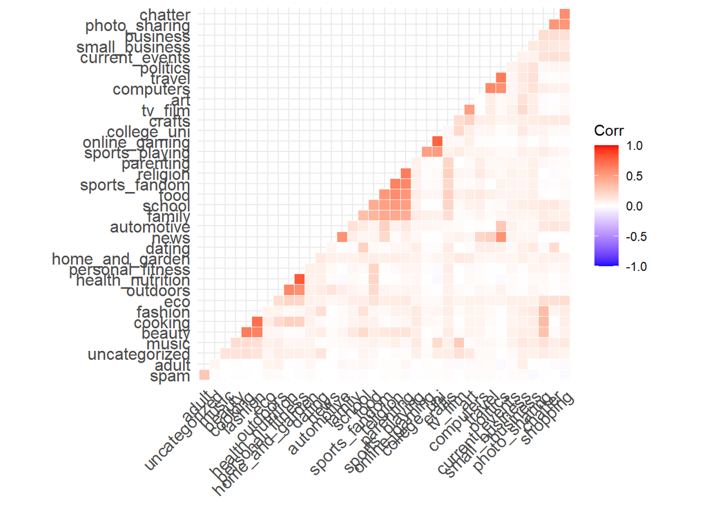

Let’s perform PCA and look at the variance explained plot -

```
## Importance of components:
##                           PC1     PC2     PC3     PC4     PC5     PC6     PC7
## Standard deviation     2.1186 1.69824 1.59388 1.53457 1.48027 1.36885 1.28577
## Proportion of Variance 0.1247 0.08011 0.07057 0.06541 0.06087 0.05205 0.04592
## Cumulative Proportion  0.1247 0.20479 0.27536 0.34077 0.40164 0.45369 0.49961
##                            PC8     PC9    PC10    PC11    PC12    PC13    PC14
## Standard deviation     1.19277 1.15127 1.06930 1.00566 0.96785 0.96131 0.94405
## Proportion of Variance 0.03952 0.03682 0.03176 0.02809 0.02602 0.02567 0.02476
## Cumulative Proportion  0.53913 0.57595 0.60771 0.63580 0.66182 0.68749 0.71225
##                           PC15    PC16   PC17    PC18    PC19    PC20    PC21
## Standard deviation     0.93297 0.91698 0.9020 0.85869 0.83466 0.80544 0.75311
## Proportion of Variance 0.02418 0.02336 0.0226 0.02048 0.01935 0.01802 0.01575
## Cumulative Proportion  0.73643 0.75979 0.7824 0.80287 0.82222 0.84024 0.85599
##                           PC22    PC23    PC24    PC25    PC26    PC27    PC28
## Standard deviation     0.69632 0.68558 0.65317 0.64881 0.63756 0.63626 0.61513
## Proportion of Variance 0.01347 0.01306 0.01185 0.01169 0.01129 0.01125 0.01051
## Cumulative Proportion  0.86946 0.88252 0.89437 0.90606 0.91735 0.92860 0.93911
##                           PC29    PC30    PC31   PC32    PC33    PC34    PC35
## Standard deviation     0.60167 0.59424 0.58683 0.5498 0.48442 0.47576 0.43757
## Proportion of Variance 0.01006 0.00981 0.00957 0.0084 0.00652 0.00629 0.00532
## Cumulative Proportion  0.94917 0.95898 0.96854 0.9769 0.98346 0.98974 0.99506
##                           PC36
## Standard deviation     0.42165
## Proportion of Variance 0.00494
## Cumulative Proportion  1.00000
```

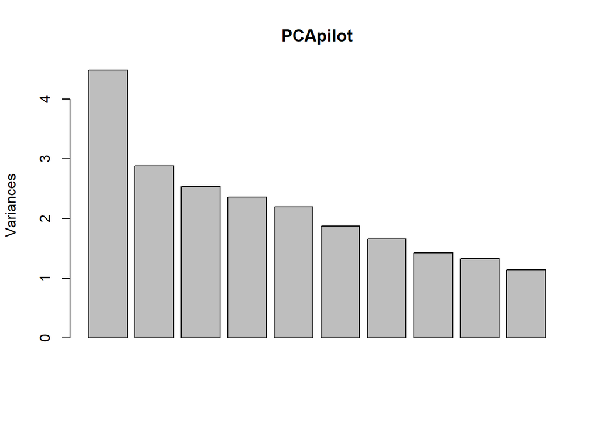

Let’s look at the Scree plot and the cumulative scree plot -

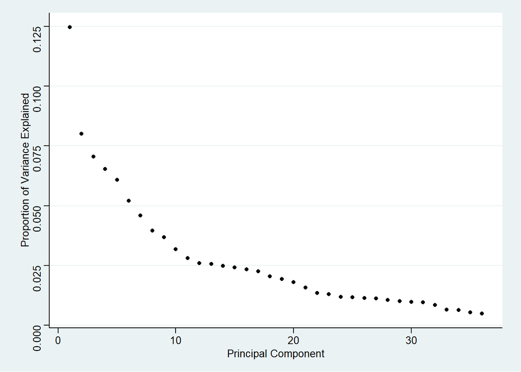

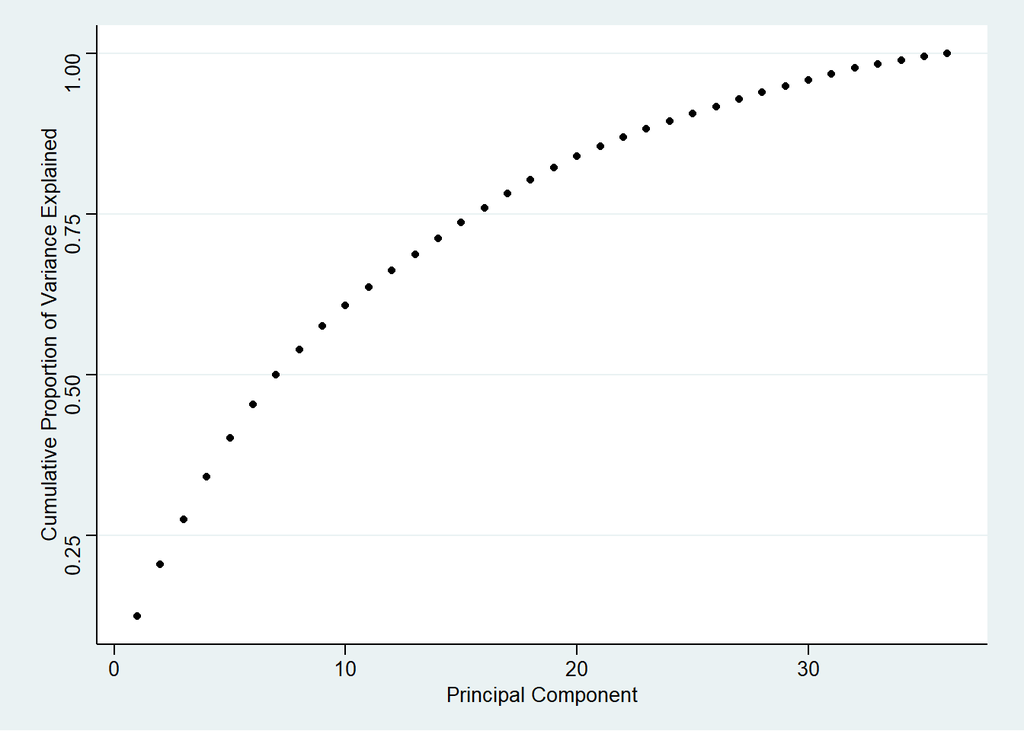

We can maybe see an elbow point around the 8th PC axis.

Let’s examine these axes and their weights -

```
##
## Loadings:
##                  PC1    PC2    PC3    PC4    PC5    PC6    PC7    PC8
## chatter                                              0.574
## current_events                                       0.178
## travel                         -0.580
## photo_sharing            0.188                       0.473
## uncategorized            0.113                              0.238
## tv_film                                                     0.602
## sports_fandom    -0.424                                           -0.147
## politics                       -0.476                             -0.301
## food             -0.381               -0.138
## family           -0.325
## home_and_garden                                             0.161
## music                    0.118                              0.234
## news                                                              -0.628
## online_gaming                                 0.611
## shopping                                             0.548
## health_nutrition                      -0.581
## college_uni                                   0.603
## sports_playing                                0.498
## cooking                  0.556        -0.102
## eco                                   -0.199         0.174
## computers                      -0.567
## business                       -0.178                0.159  0.107
## outdoors                              -0.496
## crafts           -0.138                                     0.272
## automotive                      0.154                0.103        -0.653
## art                                                         0.550
## religion         -0.453
## beauty                   0.541
## parenting        -0.435
## dating                         -0.153                              0.106
## school           -0.366
## personal_fitness                      -0.565
## fashion                  0.553
## small_business                                              0.260
## spam
## adult
##
##                  PC1   PC2   PC3   PC4   PC5   PC6   PC7   PC8
## SS loadings    1.000 1.000 1.000 1.000 1.000 1.000 1.000 1.000
## Proportion Var 0.028 0.028 0.028 0.028 0.028 0.028 0.028 0.028
## Cumulative Var 0.028 0.056 0.083 0.111 0.139 0.167 0.194 0.222
```

Looking at PC1 - It has negative weights for topics such as family, food, parenting, crafts, sports, etc. This could possibly be a segment who don’t care for family or recreational topics, somewhat of a no-nonsense business only segment (although the lack of positive weights is a little confusing).

For PC2, Positive weights are observed for photo_sharing, cooking, beauty, fashion. This could be our young adults segment who are more interested in sharing photos via social media, probably of the dishes they cook or interested in beauty and fashion tips.

For PC3, We can look at this as a casual user who’s not interested in politics or business and maybe just looking at more light-hearted posts.

For PC4, This segment seems to be averse towards any physical activity related posts. We can’t be too sure of their interests.

For PC5, This could be the sports user segment where the users are more interested in sports (maybe college games, etc).’

For PC6, This segment seems to have interest in uncategorized topics or banter, shopping and photo sharing. We can call this segment the ‘instagrammers’.

For PC7, Interests include tv and film, art, craft, music etc. We can call this segment ‘art lovers’.

We require at least 8 PC axes to define over 50% variance. This means that not a lot of clearly demarcated groups are visible and the interests are relatively independent.

Now, let’s try to combine PCA and clustering to obtain possibly better results that are more interpretable -

```
## [1] "Filter dataset on spam and Adult flags"
```

```
## [1] "Plotting the missing values and categorical columns"
```

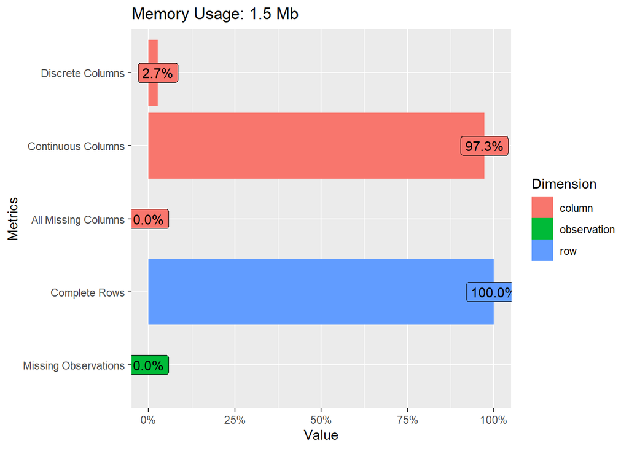

```
## [1] "Plotting the distribution of variables"
```

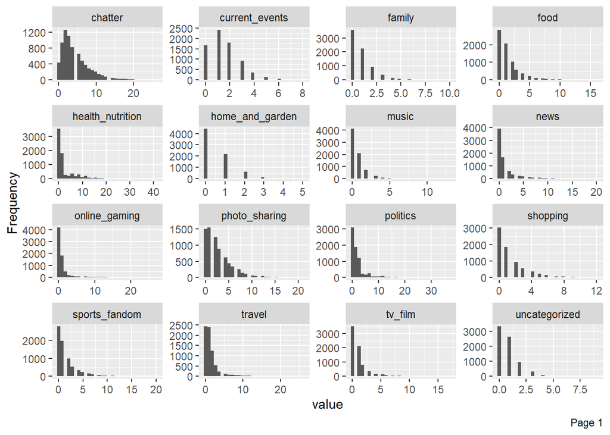

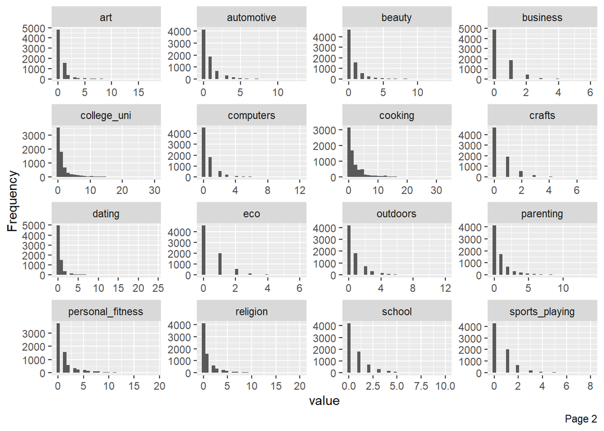

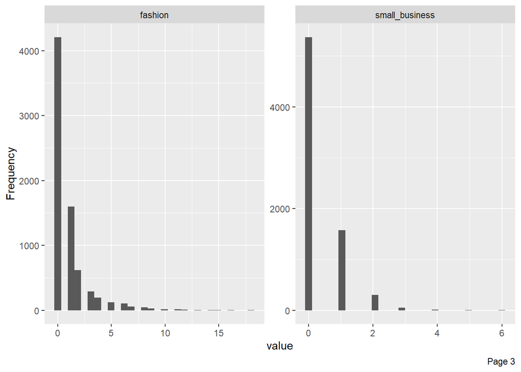

```
## [1] "Plotting the correlation of items"
```

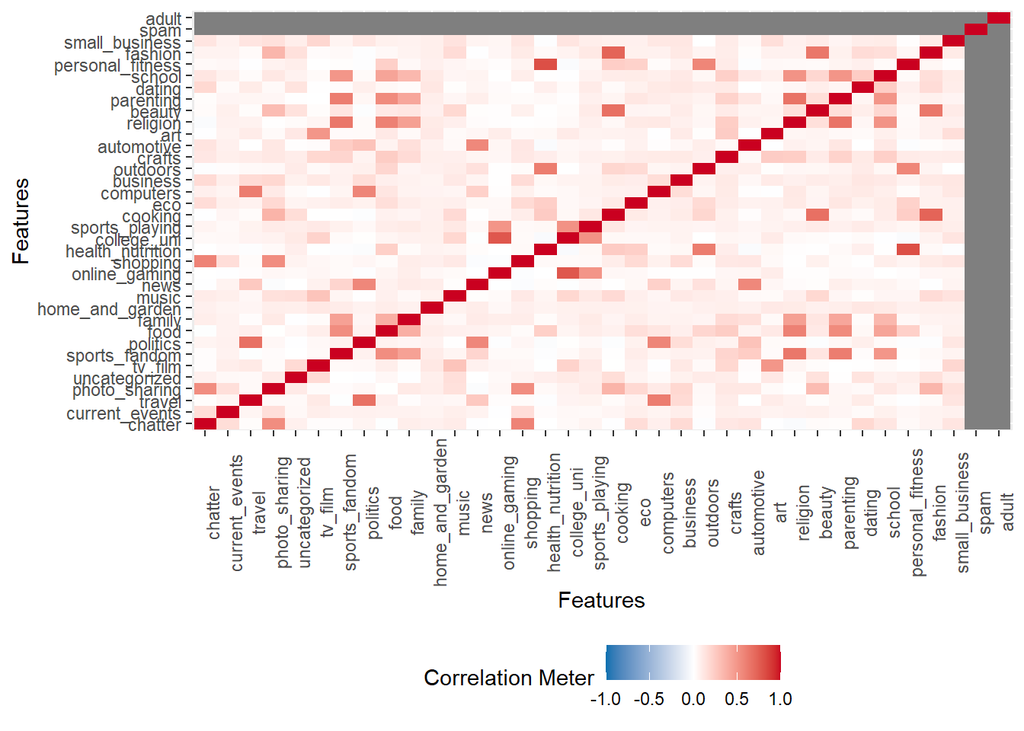

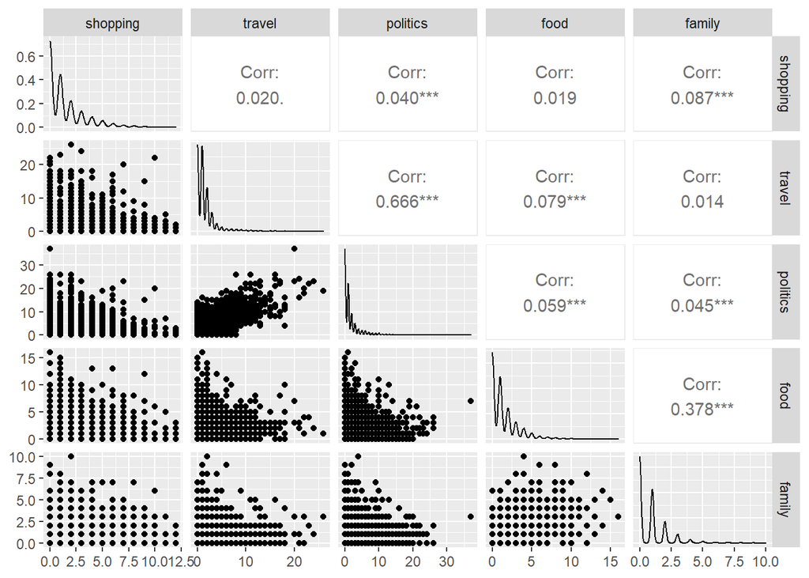

```
## [1] "It seems that tv_films is correlated with school, beauty and art, lets try to build a PCA model on top of it"
```

```
## [1] "Performaing a PCA analysis to understand the composition"
```

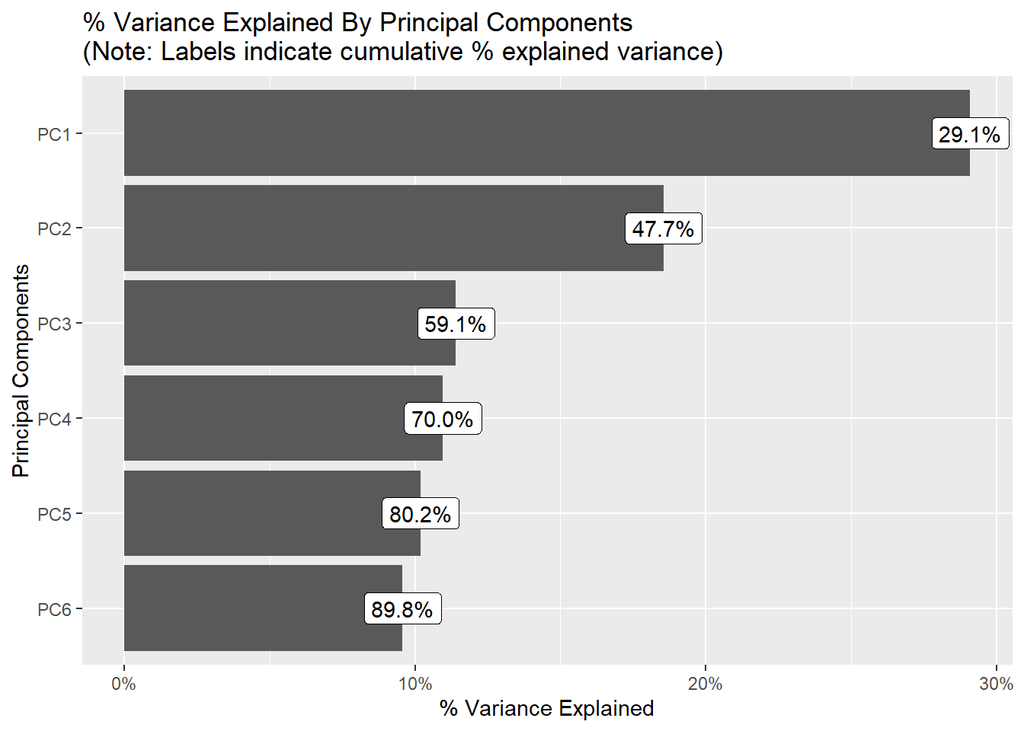

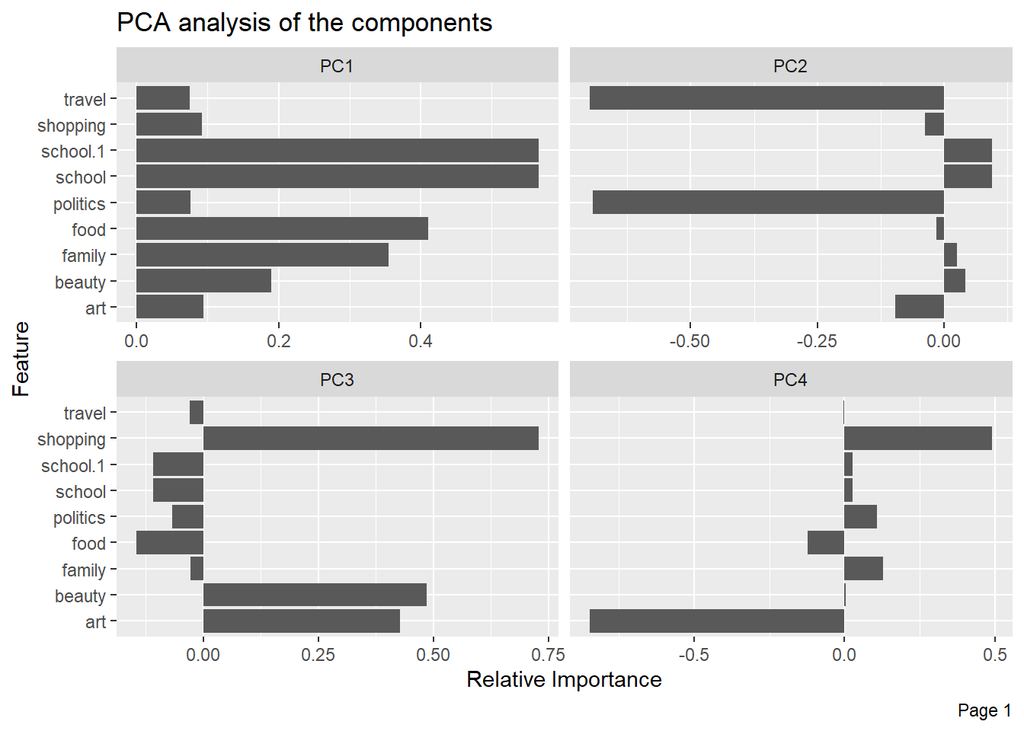

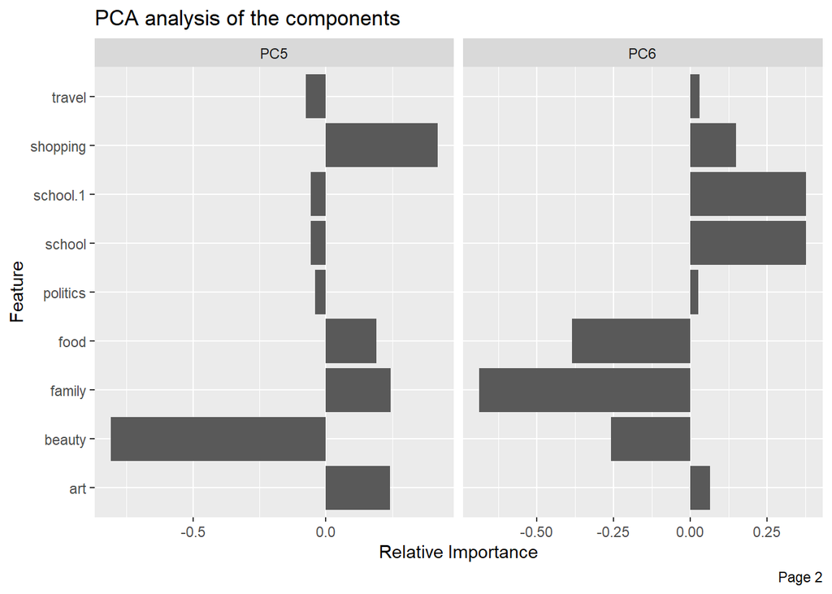

```
## [1] "Lets try to cluster the most correlated variables of this data using Kmeans clustering"
```

```
##      politics     travel      school      beauty         art
## 1 -0.05124863  0.2661466  0.13111182 -0.01769018  3.74215419
## 2 -0.19572837 -0.1808596  1.23985885  1.26962059 -0.08900009
## 3 -0.20037142 -0.2186171 -0.33186097 -0.32436755 -0.20093181
## 4  2.96827449  2.9051058 -0.01004564 -0.08008951 -0.10407236
```

```
## [1] "Lets look at the clusters for this set"
```

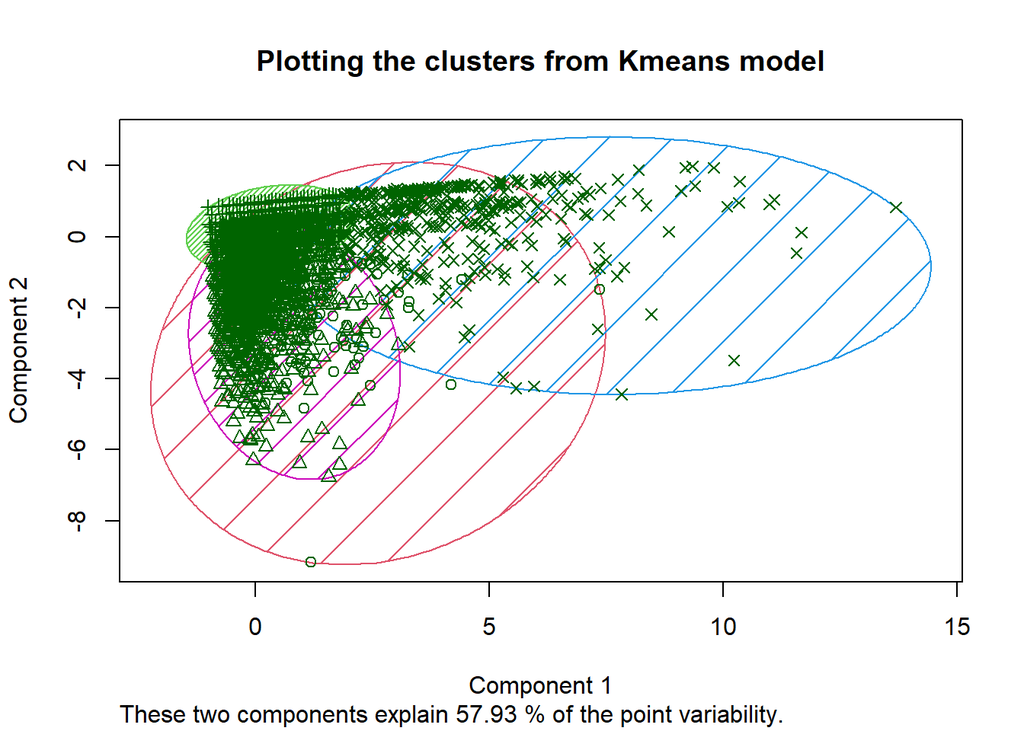

```
## [1] "Now lets try to combine PCA with Clustering for the most correlated variables"
```

```
## [1] "We want to examine the cluster memberships for each #observation"
```

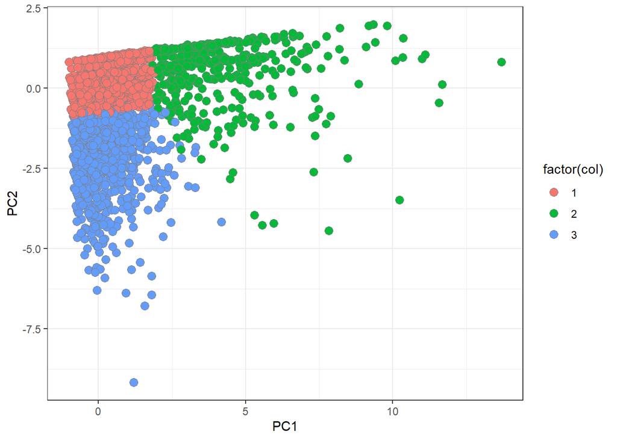

```
## [1] "Number of members in each cluster"
```

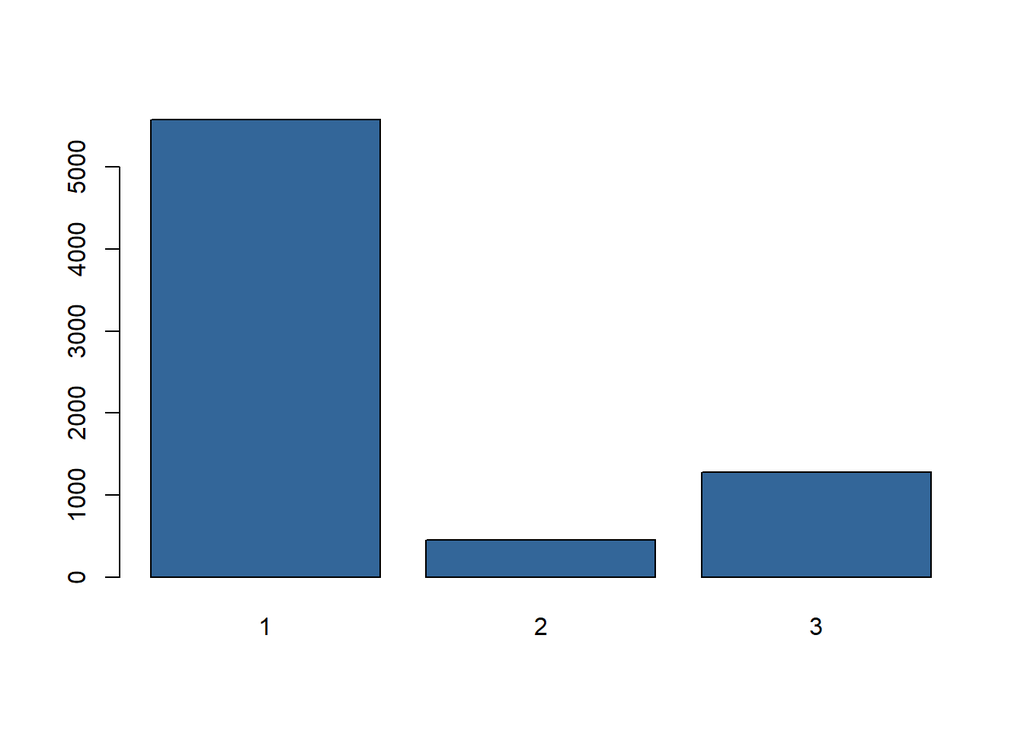

```
## [1] "Plotting the cluster"
```

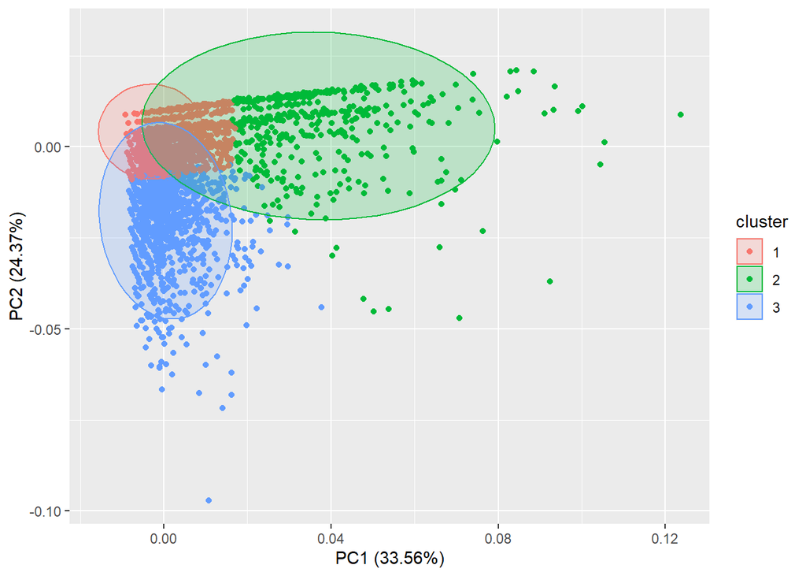

```
## [1] "The Final Market segments"
```

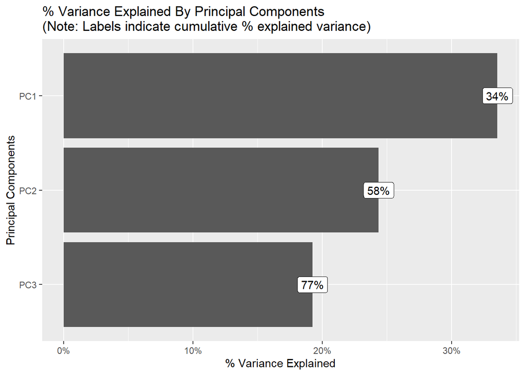

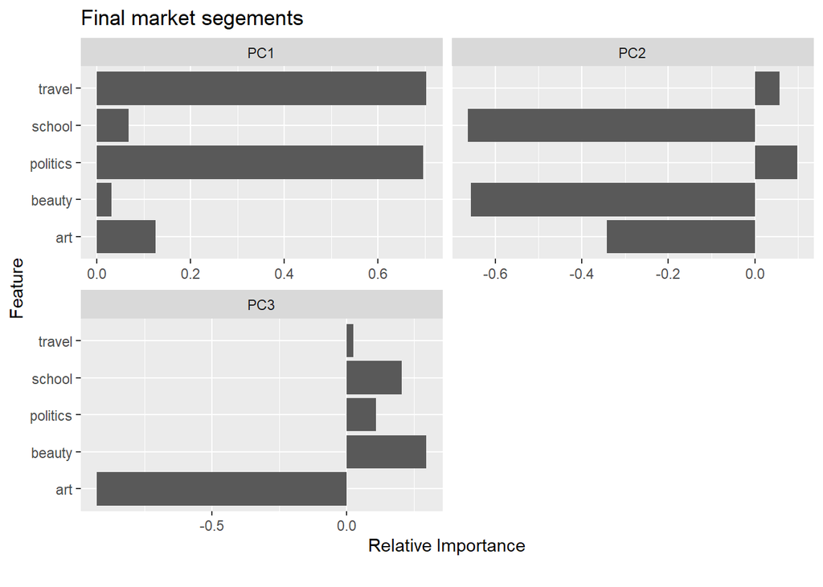

We observed that using PCA in combination with Kmeans clustering gave us the best separation for components, we can use these market segments as our final set.

## The Reuters corpus

Revisit the Reuters C50 text corpus that we briefly explored in class. Your task is simple: tell an interesting story, anchored in some analytical tools we have learned in this class, using this data. For example:  
- you could cluster authors or documents and tell a story about what you find.  
- you could look for common factors using PCA.  
- you could train a predictive model and assess its accuracy. (Yes, this is a supervised learning task, but it potentially draws on a lot of what you know about unsupervised learning, since constructing features for a document might involve dimensionality reduction.)  
- you could do anything else that strikes you as interesting with this data.

Describe clearly what question you are trying to answer, what models you are using, how you pre-processed the data, and so forth. Make sure you include at least *one* really interesting plot (although more than one might be necessary, depending on your question and approach.)

Format your write-up in the following sections, some of which might be quite short:  
- Question: What question(s) are you trying to answer? - Approach: What approach/statistical tool did you use to answer the questions? - Results: What evidence/results did your approach provide to answer the questions? (E.g. any numbers, tables, figures as appropriate.) - Conclusion: What are your conclusions about your questions? Provide a written interpretation of your results, understandable to stakeholders who might plausibly take an interest in this data set.

Regarding the data itself: In the C50train directory, you have 50 articles from each of 50 different authors (one author per directory). Then in the C50test directory, you have another 50 articles from each of those same 50 authors (again, one author per directory). This train/test split is obviously intended for building predictive models, but to repeat, you need not do that on this problem. You can tell any story you want using any methods you want. Just make it compelling!

Note: if you try to build a predictive model, you will need to figure out a way to deal with words in the test set that you never saw in the training set. This is a nontrivial aspect of the modeling exercise. (E.g. you might simply ignore those new words.)

This question will be graded according to three criteria:  
1. the overall “interesting-ness” of your question and analysis.  
2. the clarity of your description. We will be asking ourselves: could your analysis be reproduced by a competent data scientist based on what you’ve said? (That’s good.) Or would that person have to wade into the code in order to understand what, precisely, you’ve done? (That’s bad.)  
3. technical correctness (i.e. did you make any mistakes in execution or interpretation?)

### Solution:

- **Question:** What are the most frequently used words across the entire dataset and are they the same words which are used in the most number of documents?
- **Approach:** We used the DocumentTermMatrix to calculate the frequencies of word across the entire dataset across authors and we used the inverse document frequency to calculate the usage of these words across documents and plotted these on word cloud to understand the same.

```
## [1] "load data for all authors"
```

```
## [1] "list of directory names/Authors"
```

```
## [1] "DocumentTermMatrix"    "simple_triplet_matrix"
```

```
## [1] 801
```

```
## [1] "most frequent and least frequent words across the entire dataset"
```

```
##          name count
##  1:      said 19851
##  2: character 10013
##  3:      year  6899
##  4:      will  5873
##  5:   percent  5270
##  6:   million  4848
##  7:       new  3508
##  8:    market  3215
##  9:   company  3200
## 10:   billion  3012
```

```
##           name count
##  1:      thing   130
##  2:     cchina   132
##  3:     moving   133
##  4: considered   133
##  5:     either   134
##  6:    success   134
##  7:       ever   137
##  8:    initial   138
##  9:     figure   138
## 10:    quickly   139
```

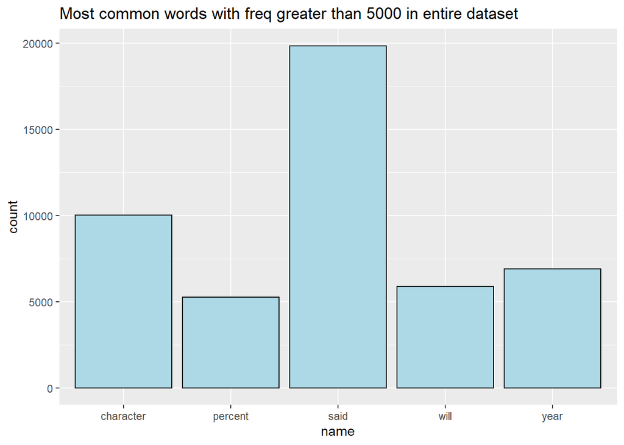

```
## [1] "Word cloud of words with min frequency of 1000 in entire dataset"
```

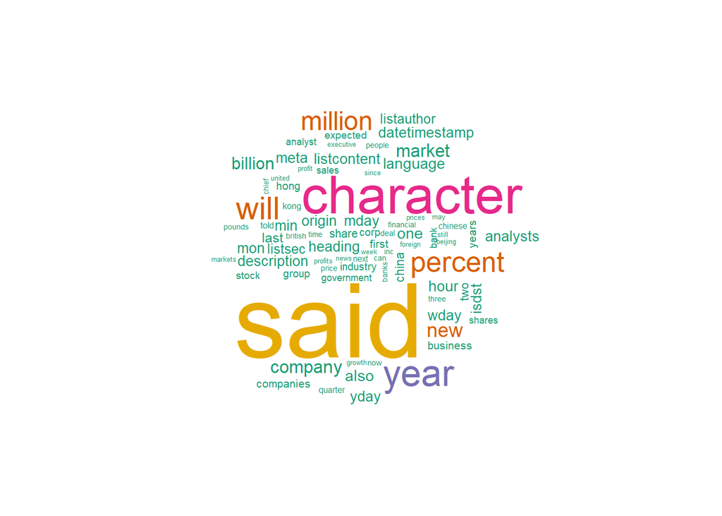

```
## [1] 801
```

```
## [1] "most frequent and least frequent words by number of documents"
```

```
##        name    count
##  1:    hong 29.79466
##  2:   china 27.24980
##  3:    kong 24.50645
##  4: million 23.26764
##  5:    bank 20.74283
##  6: percent 20.24720
##  7: chinese 20.16345
##  8: billion 19.63257
##  9:   sales 18.38453
## 10: company 18.26743
```

```
##              name count
##  1:     character     0
##  2: datetimestamp     0
##  3:   description     0
##  4:       heading     0
##  5:          hour     0
##  6:         isdst     0
##  7:      language     0
##  8:   listcontent     0
##  9:          mday     0
## 10:          meta     0
```

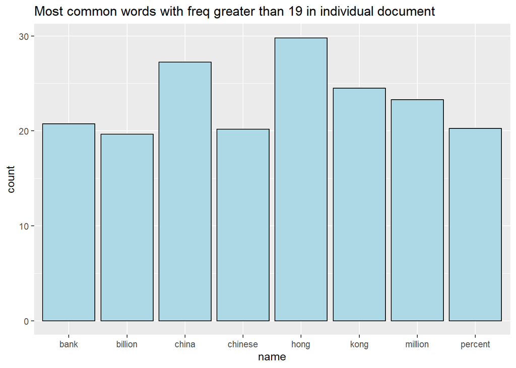

```
## [1] "Word cloud of words with min frequency of 15 in individual dataset"
```

[figure not shown]

- **Results:** The word clouds have been generated and we can see that these are not the same, which means that the words which have the highest frequency are not he ones which have been used in most number of documents.
- **Conclusion:** We can conclude that the data distribution is such that some words are used much more frequently within certain documents here.
- **Question:** Based on TF-IDF values, can we predict the author of a document?
- **Approach:** Let’s first start by getting names of all the authors -

```
##  [1] "AaronPressman"     "AlanCrosby"        "AlexanderSmith"
##  [4] "BenjaminKangLim"   "BernardHickey"     "BradDorfman"
##  [7] "DarrenSchuettler"  "DavidLawder"       "EdnaFernandes"
## [10] "EricAuchard"       "FumikoFujisaki"    "GrahamEarnshaw"
## [13] "HeatherScoffield"  "JanLopatka"        "JaneMacartney"
## [16] "JimGilchrist"      "JoWinterbottom"    "JoeOrtiz"
## [19] "JohnMastrini"      "JonathanBirt"      "KarlPenhaul"
## [22] "KeithWeir"         "KevinDrawbaugh"    "KevinMorrison"
## [25] "KirstinRidley"     "KouroshKarimkhany" "LydiaZajc"
## [28] "LynneO'Donnell"    "LynnleyBrowning"   "MarcelMichelson"
## [31] "MarkBendeich"      "MartinWolk"        "MatthewBunce"
## [34] "MichaelConnor"     "MureDickie"        "NickLouth"
## [37] "PatriciaCommins"   "PeterHumphrey"     "PierreTran"
## [40] "RobinSidel"        "RogerFillion"      "SamuelPerry"
## [43] "SarahDavison"      "ScottHillis"       "SimonCowell"
## [46] "TanEeLyn"          "TheresePoletti"    "TimFarrand"
## [49] "ToddNissen"        "WilliamKazer"
```

Now, let’s create a vectorized matrix of word counts from the entire corpus against each author (Bag of Words model where ‘author’ is the dependent variable).

What does this matrix consist of?

```
## <<DocumentTermMatrix (documents: 5000, terms: 45853)>>
## Non-/sparse entries: 1083147/228181853
## Sparsity           : 100%
## Maximal term length: 45
## Weighting          : term frequency (tf)
```

It’s a very sparse matrix.

```
## [1] "DocumentTermMatrix"    "simple_triplet_matrix"
```

```
## <<DocumentTermMatrix (documents: 5000, terms: 3378)>>
## Non-/sparse entries: 844216/16045784
## Sparsity           : 95%
## Maximal term length: 18
## Weighting          : term frequency (tf)
```

Wow! That’s quite a reduction! Now that we’ve removed a lot of such randomly occurring words (variance), let’s train a Multinomial Naive Bayes model and look at it’s accuracy -

```
##                 y_test_pred
## y_test           AaronPressman AlanCrosby AlexanderSmith BenjaminKangLim
##   AaronPressman             16          0              0               0
##   AlanCrosby                 0         23              0               0
##   AlexanderSmith             0          0             13               0
##                 y_test_pred
## y_test           BernardHickey BradDorfman DarrenSchuettler DavidLawder
##   AaronPressman              0           0                0           0
##   AlanCrosby                 0           0                0           0
##   AlexanderSmith             0           0                0           0
##                 y_test_pred
## y_test           EdnaFernandes EricAuchard FumikoFujisaki GrahamEarnshaw
##   AaronPressman              0           0              0              0
##   AlanCrosby                 0           0              0              0
##   AlexanderSmith             0           0              0              0
##                 y_test_pred
## y_test           HeatherScoffield JaneMacartney JanLopatka JimGilchrist
##   AaronPressman                 0             0          0            0
##   AlanCrosby                    0             0          2            0
##   AlexanderSmith                0             0          0            0
##                 y_test_pred
## y_test           JoeOrtiz JohnMastrini JonathanBirt JoWinterbottom KarlPenhaul
##   AaronPressman         0            0            0              0           0
##   AlanCrosby            0            0            0              0           0
##   AlexanderSmith        1            0            1              1           0
##                 y_test_pred
## y_test           KeithWeir KevinDrawbaugh KevinMorrison KirstinRidley
##   AaronPressman          0              0             0             0
##   AlanCrosby             0              0             0             0
##   AlexanderSmith         0              0             0             0
##                 y_test_pred
## y_test           KouroshKarimkhany LydiaZajc LynneO'Donnell LynnleyBrowning
##   AaronPressman                  0         0              0               0
##   AlanCrosby                     0         0              0               0
##   AlexanderSmith                 0         0              0               0
##                 y_test_pred
## y_test           MarcelMichelson MarkBendeich MartinWolk MatthewBunce
##   AaronPressman                0            0          0            0
##   AlanCrosby                   0            0          0            0
##   AlexanderSmith               0            0          0            0
##                 y_test_pred
## y_test           MichaelConnor MureDickie NickLouth PatriciaCommins
##   AaronPressman              0          0         0               0
##   AlanCrosby                 0          0         0               0
##   AlexanderSmith             0          0         0               0
##                 y_test_pred
## y_test           PeterHumphrey PierreTran RobinSidel RogerFillion SamuelPerry
##   AaronPressman              0          0          0            0           0
##   AlanCrosby                 0          0          0            0           0
##   AlexanderSmith             0          0          0            0           1
##                 y_test_pred
## y_test           SarahDavison ScottHillis SimonCowell TanEeLyn TheresePoletti
##   AaronPressman             0           0           0        0              0
##   AlanCrosby                0           0           0        0              0
##   AlexanderSmith            0           0           3        0              0
##                 y_test_pred
## y_test           TimFarrand ToddNissen WilliamKazer
##   AaronPressman           0          0            0
##   AlanCrosby              0          0            0
##   AlexanderSmith          1          0            0
```

Let’s look at the accuracy -

```
## [1] 0.793
```

We get almost 80% accuracy (79.3%) on a simple Naive Bayes model.

## Association rule mining

Revisit the notes on association rule mining and the R example on music playlists: playlists.R and playlists.csv. Then use the data on grocery purchases in groceries.txt and find some interesting association rules for these shopping baskets. The data file is a list of shopping baskets: one person’s basket for each row, with multiple items per row separated by commas. Pick your own thresholds for lift and confidence; just be clear what these thresholds are and say why you picked them. Do your discovered item sets make sense? Present your discoveries in an interesting and visually appealing way.

Notes: - This is an exercise in visual and numerical story-telling. Do be clear in your description of what you’ve done, but keep the focus on the data, the figures, and the insights your analysis has drawn from the data, rather than technical details.  
- The data file is a list of baskets: one row per basket, with multiple items per row separated by commas. You’ll have to cobble together your own code for processing this into the format expected by the “arules” package. This is not intrinsically all that hard, but it is the kind of data-wrangling wrinkle you’ll encounter frequently on real problems, where your software package expects data in one format and the data comes in a different format. Figuring out how to bridge that gap is part of the assignment, and so we won’t be giving tips on this front.

### Solution:

From the given list, let’s first look at which items are bought the most by frequency -

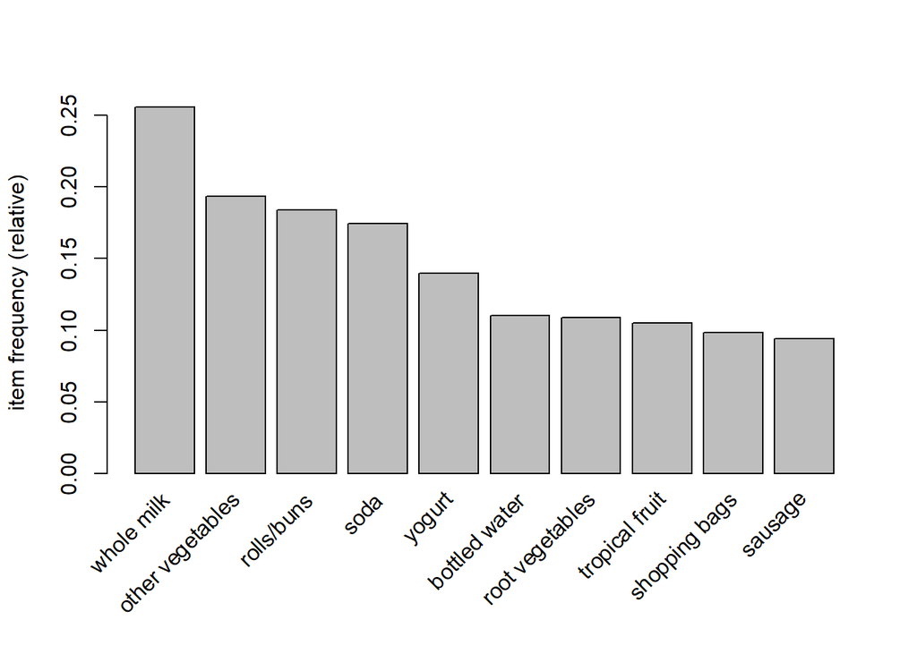

Now, let’s look at a graph of confidence vs support for all the rules we obtain from apriori -

```
## Apriori
##
## Parameter specification:
##  confidence minval smax arem  aval originalSupport maxtime support minlen
##         0.1    0.1    1 none FALSE            TRUE       5   0.005      1
##  maxlen target  ext
##       4  rules TRUE
##
## Algorithmic control:
##  filter tree heap memopt load sort verbose
##     0.1 TRUE TRUE  FALSE TRUE    2    TRUE
##
## Absolute minimum support count: 49
##
## set item appearances ...[0 item(s)] done [0.00s].
## set transactions ...[169 item(s), 9835 transaction(s)] done [0.00s].
## sorting and recoding items ... [120 item(s)] done [0.00s].
## creating transaction tree ... done [0.00s].
## checking subsets of size 1 2 3 4 done [0.00s].
## writing ... [1582 rule(s)] done [0.00s].
## creating S4 object  ... done [0.00s].
```

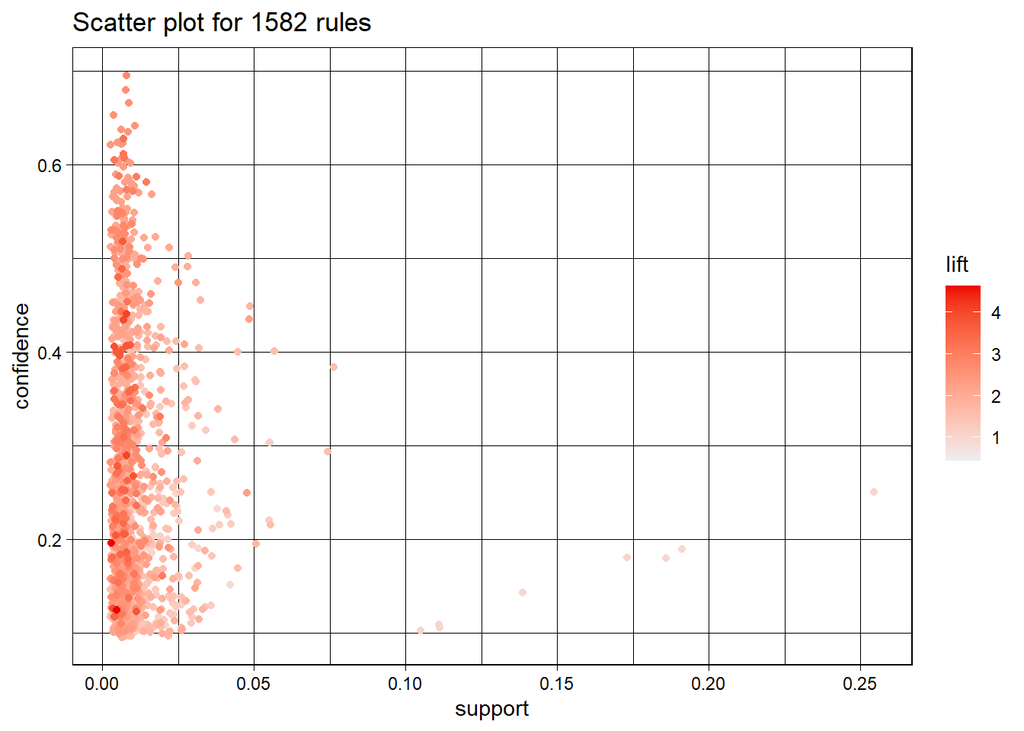

We can also see that a majority of rules that have high lift (3 or more) tend to have lower confidence.

Let’s color the points based on order of the rules -

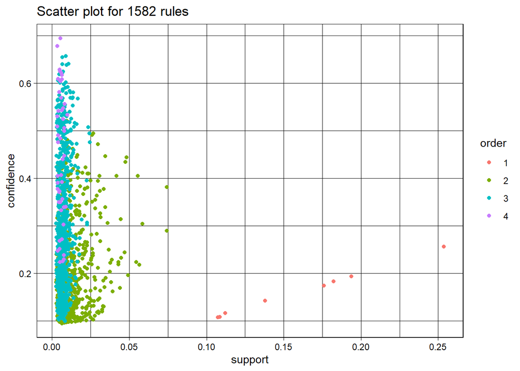

Most of the rules are of order 2 and 3. Most of order 1 rules have very low confidence and most of order 4 rules have relatively high confidence and low support.

Let’s look at a graphical representation of all rules that have a confidence of more than 0.15 and a lift of more than 2 -

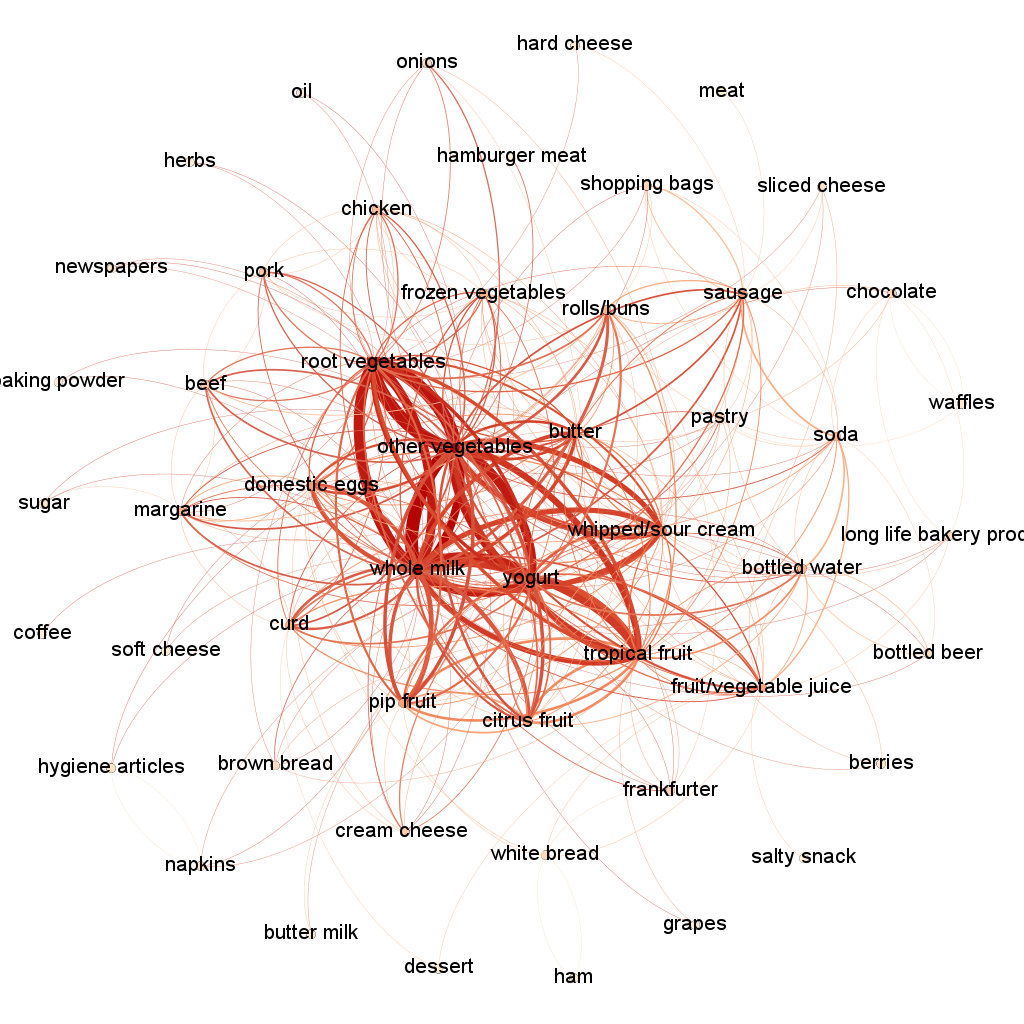

Graph weighted by confidence

A majority of rules contain whole milk, vegetables, root vegetables, yogurt, eggs, etc.

Items like napkins, buttermilk, salty snacks, berries, etc are not bought too often as compared to other items and they have low confidence as well. Items like sliced cheese, oil etc aren’t bought that often either but have comparatively high confidence.